# Survey Methodology II - Final Group Project : Discrimination in the EU

### Generalized linear mixed model with both individual and country level features

We will run a generalized linear mixed model after introducing country-level data, in order to discover these country-level data are sufficient to explain the random effects or not.

We first recover the variable nationality in the data set:

```r
uniqid_nationality<- data_joint |>
  dplyr::select(country,nationality)

data_numeric <- data_joint2[, sapply(data_joint2, is.numeric)]
data_final_selected <- data_numeric |>
  dplyr::select(country, all_of(selected_vars2), yes_transgender_change_documents) |>
  dplyr::select(-positive_school_inform_diversity_transgender_ind,
                -positive_school_inform_diversity_intersex_ind) |>
  dplyr::select(-all_of(non_significant_vars))

data_selected_with_nationality<- data_final_selected |>
  left_join(uniqid_nationality, by="country") |>
  dplyr::select(-country)
```

```r
# Setting up parallel computing
num_cores <- detectCores() - 1
plan(multisession, workers = num_cores)
options(mem.maxVSize = 32 * 1024^3)
Sys.setenv(R_MAX_VSIZE="32GB")

#sample the data
set.seed(123)
sample_data <- data_selected_with_nationality[sample(1:nrow(data_selected_with_nationality),
                                                      size = floor(0.0005 * nrow(data_selected_with_nationality))), ]

#Selecting only variables with high significance (0 ‘***’ )
glmm_model_final <- glmer(yes_transgender_change_documents ~
positive_lgb_no_problem_same_sex_relationship_ind+
positive_lgb_rights_equal_heterosexual_ind+
positive_lgb_allow_same_sex_marriage_ind+
positive_energy_clean_ind+
yes_contact_lgb+
positive_census_info_disability_ind+
comfortable_elected_homosexual_bisexual_ind+
comfortable_elected_transgender_ind+
yes_third_gender_option+
`Gender Development Index`+
`Income richest 1 percent (%)`+
sum_laws + (1 | nationality),
                          data = sample_data,
                          family = binomial,
                          control = glmerControl(optimizer = "bobyqa",
                                                optCtrl = list(maxfun = 1000000)))
plan(sequential)
```

```r
summary(glmm_model_final)
```

```
Generalized linear mixed model fit by maximum likelihood (Laplace
  Approximation) [glmerMod]
 Family: binomial  ( logit )
Formula:
yes_transgender_change_documents ~ positive_lgb_no_problem_same_sex_relationship_ind +
    positive_lgb_rights_equal_heterosexual_ind + positive_lgb_allow_same_sex_marriage_ind +
    positive_energy_clean_ind + yes_contact_lgb + positive_census_info_disability_ind +
    comfortable_elected_homosexual_bisexual_ind + comfortable_elected_transgender_ind +
    yes_third_gender_option + `Gender Development Index` + `Income richest 1 percent (%)` +
    sum_laws + (1 | nationality)
   Data: sample_data
Control: glmerControl(optimizer = "bobyqa", optCtrl = list(maxfun = 1e+06))

     AIC      BIC   logLik deviance df.resid
 11223.0  11328.1  -5597.5  11195.0    13403

Scaled residuals:
    Min      1Q  Median      3Q     Max
-7.1210 -0.4587  0.1664  0.3773  5.7720

Random effects:
 Groups      Name        Variance Std.Dev.
 nationality (Intercept) 0.1054   0.3246
Number of obs: 13417, groups:  nationality, 28

Fixed effects:
                                                   Estimate Std. Error z value
(Intercept)                                       -13.43935    4.03855  -3.328
positive_lgb_no_problem_same_sex_relationship_ind   0.38263    0.07347   5.208
positive_lgb_rights_equal_heterosexual_ind          0.59778    0.06982   8.562
positive_lgb_allow_same_sex_marriage_ind            0.34484    0.07355   4.688
positive_energy_clean_ind                           0.46315    0.08296   5.583
yes_contact_lgb                                     0.48994    0.05569   8.797
positive_census_info_disability_ind                 0.25604    0.05160   4.962
comfortable_elected_homosexual_bisexual_ind         0.39806    0.06697   5.944
comfortable_elected_transgender_ind                 0.27372    0.06455   4.240
yes_third_gender_option                             2.58015    0.05604  46.039
`Gender Development Index`                         10.93382    4.05868   2.694
`Income richest 1 percent (%)`                     -0.06312    0.02289  -2.757
sum_laws                                            0.08374    0.01535   5.454
                                                  Pr(>|z|)
(Intercept)                                       0.000875 ***
positive_lgb_no_problem_same_sex_relationship_ind 1.91e-07 ***
positive_lgb_rights_equal_heterosexual_ind         < 2e-16 ***
positive_lgb_allow_same_sex_marriage_ind          2.76e-06 ***
positive_energy_clean_ind                         2.37e-08 ***
yes_contact_lgb                                    < 2e-16 ***
positive_census_info_disability_ind               6.96e-07 ***
comfortable_elected_homosexual_bisexual_ind       2.79e-09 ***
comfortable_elected_transgender_ind               2.23e-05 ***
yes_third_gender_option                            < 2e-16 ***
`Gender Development Index`                        0.007061 **
`Income richest 1 percent (%)`                    0.005826 **
sum_laws                                          4.91e-08 ***
---
Signif. codes:  0 '***' 0.001 '**' 0.01 '*' 0.05 '.' 0.1 ' ' 1
```

```
Correlation matrix not shown by default, as p = 13 > 12.
Use print(x, correlation=TRUE)  or
    vcov(x)        if you need it
```

```
optimizer (bobyqa) convergence code: 0 (OK)
Model is nearly unidentifiable: large eigenvalue ratio
 - Rescale variables?
```

We can observe that **σ_random² reduces into 0.1054**, and **ICC reduces into 0.0954**, which means that about **9.54% of the variance comes from the random effect (nationality**), less than **26.57% of ICC from the previous glmm model without national level data**. This shows that these added country-level data have covered an important part of differences among countries.

This plot shows the new distribution of random intercepts, and we can observe **the scope of x axis reduces from (-2,2) to (-0.75, 0.50). This visualizes perfectly that more country-level variability is explained now**.

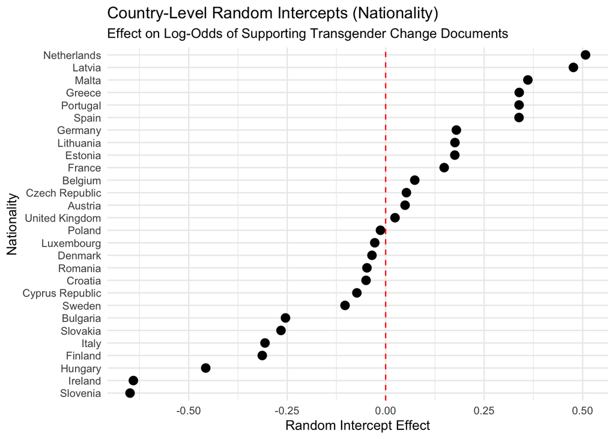

```r
ranef_country2 <- ranef(glmm_model_final)$nationality

ranef_country2_df <- data.frame(
  nationality = rownames(ranef_country2),
  effect = ranef_country2[, "(Intercept)"]
)

ranef_country2_df <- ranef_country2_df |>
  arrange(effect)

ggplot(ranef_country2_df, aes(x = reorder(nationality, effect), y = effect)) +
  geom_point(size = 3) +
  geom_hline(yintercept = 0, linetype = "dashed", color = "red") +
  coord_flip() +
  labs(
    title = "Country-Level Random Intercepts (Nationality)",
    subtitle = "Effect on Log-Odds of Supporting Transgender Change Documents",
    x = "Nationality",
    y = "Random Intercept Effect"
  ) +
  theme_minimal()
```